# Lecture 6. Regression problem: quality measures and regularization

## Reminder

- Regression problem statement
- Linear least squares
- Nonlinear least squares
- Gauss-Newton and Levenberg-Marquardt methods

## Today lecture

- Regression quality measures
- What to do when the design matrix is not full-rank?
- Probabilistic interpretation

## Quality measures

- Train and test loss
- Coefficient of determination $R^2$ $$ R^2 = 1 - \frac{S_{res}}{S_{tot}}, $$ where $S_{res} = \| y - \hat{y} \|^2_2$ and $S_{tot} = \| y - \bar{y}\|^2_2$. Closer to 1, better the model

Cons: $R^2$ increases when more features are added

- Scikit-learn uses this measure to score the regression model
- Attempt to treat the cons: adjusted $R^2$ — $\bar{R}^2$ $$ \bar{R}^2 = 1 - (1 - R^2) \frac{n-1}{n-m} $$

Here $x \in \mathbb{R}^n, y \in \mathbb{R}^m$

### AIC and BIC - the lower the better

- Akaike Information Criterion $$ AIC = n \log \left(\frac{S_{res}}{n}\right) + 2m, $$ where $n$ is a number of samples, $m$ is a number of features
- Bayesian Information Criterion $$ BIC = n \log \left(\frac{S_{res}}{n}\right) + 2m \log(n) $$

## Statistical tests

- $t$-test

Test significance of every feature in explanation of the target vector:

$$ H_0: w_j = 0 \quad H_1: w_j \neq 0 $$

- $F$-test

Test if the linear model is adequate

$$ H_0: w_1, w_2, \ldots, w_n = 0 \quad H_1: \exists k: \; w_k \neq 0 $$

- Normality of the residuals

Again,

$$ \|Xw - y\|_2^2 \to \min_w $$

Normal equation is the solution:

$$ w^* = (X^*X)^{-1}X^* y = X^\dagger y $$

Given the solution let's turn it back to the problem:

$$ \|X(X^*X)^{-1}X^* y - y\|_2^2 \to \min_w $$

$$ \|\Pi y - y\|_2^2 \to \min_w $$

Where $\Pi = X(X^*X)^{-1}X^*$ is the projector matrix. It means, that least squares is just the projection of $y$ to the linear hull of columns of $X$ :)

Let us introduce covariation matrix $\Sigma = X^* X$ (Note, that if all features are normalized, it is just correlation matrix). What should we do if its condition number $\mu(\Sigma) = \dfrac{\lambda_{max}}{\lambda_{min}}$ is huge?

## Multicollinearity

**Definition.** The phenomenon of linear dependencies between features is called *multicollinearity*.

**Corollary.** The matrix $X^{\top}X$ is singular and normal equation can not be solved as it is.

**Q:** how to deal with this problem?

## Regularization

**Definition. (not formal)** Regularization is a process of introduction to the model additional information to solve incorrect problems

Examples:

- improve stability by changing objective function
- provide uniqueness of the solution by adding constraints
- transform objective function to provide finite solution

### Tikhonov regularization (Ridge or $\ell_2$)

$$ \min_w \|Xw - y \|^2_2 + \alpha\|w\|^2_2, \quad \alpha > 0 $$

The solution changes:

$$ w^* = (X^*X + \alpha I)^{-1}X^* y $$

All the eugunvalues of $\Sigma$ now increased to $\alpha$, but the eigenvectors are still the same. Let us also look to the trace of projection matrix $\Pi$ under such transformation:

Before: $$ \text{tr}\;\Pi =\text{tr}\; X(X^*X)^{-1}X^* = \text{tr}\; X^*X(X^*X)^{-1} = \text{tr}\; I = n $$

After: $$ \text{tr}\;\Pi = \text{tr}\; X(X^*X + \alpha I)^{-1}X^* = \text{tr}\; \text{diag}\; \dfrac{\lambda_i}{\lambda_i + \alpha} = \sum_i \dfrac{\lambda_i}{\lambda_i + \alpha} \leq n $$

#### Lasso ($\ell_1$)

$$ \min_w \|Xw - y \|^2_2 + \alpha\|w\|_1, \quad \alpha > 0 $$

Specifics:

- nondifferential but convex objective function
- relaxation of the $\ell_0$ "norm"
- sparse solution

### Ridge vs. Lasso

[figure not shown]

### Elastic Net

$$ \min_w \|Xw - y \|^2_2 + \alpha \rho\|w\|_1 + \alpha\frac{1-\rho}{2}\| w \|^2_2, \quad \rho \in [0, 1], \alpha > 0 $$

Specifics:

- combination of Lasso and Ridge
- more stable than Lasso

### General form of objectives in machine learning

$$ \min_w \ell(w|X, y) + R(w), $$ where $\ell(w|X, y) = \sum\limits_{i=1}^m \ell_i(w|x_i, y_i)$ is a loss function and $R(w)$ is a regulaization term

- The objectives of such structure is called *composite* functions.
- For this structure there exist special optimization approaches and theory
- Since loss is a sum of loss for every sample, *distributed optimization* is active too

## Probability interpretation

- Maximum likelihood estimation
- Normal distributed residuals - linear least squares problem
- Laplace distributed residuals - MAE minimization
- Bayesian methodology - later in the course

Let's see to logistic regression example

```python
import pandas as pd
import numpy as np
from sklearn import preprocessing
import matplotlib.pyplot as plt
plt.rc("font", size=14)
from sklearn.linear_model import LogisticRegression
from sklearn.cross_validation import train_test_split
import seaborn as sns
sns.set(style="white")
sns.set(style="whitegrid", color_codes=True)
```

```python
data = pd.read_csv('../files/banking.csv', header=0)
data = data.dropna()
print(data.shape)
print(list(data.columns))
```

```
(41188, 21)
['age', 'job', 'marital', 'education', 'default', 'housing', 'loan', 'contact', 'month', 'day_of_week', 'duration', 'campaign', 'pdays', 'previous', 'poutcome', 'emp_var_rate', 'cons_price_idx', 'cons_conf_idx', 'euribor3m', 'nr_employed', 'y']
```

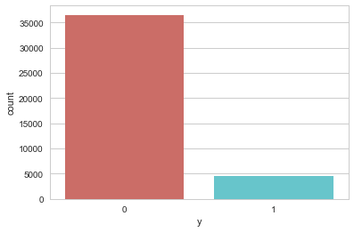

```python
sns.countplot(x='y',data=data, palette='hls')
plt.show()
```

```python
data.isnull().sum()
```

```
age               0
job               0
marital           0
education         0
default           0
housing           0
loan              0
contact           0
month             0
day_of_week       0
duration          0
campaign          0
pdays             0
previous          0
poutcome          0
emp_var_rate      0
cons_price_idx    0
cons_conf_idx     0
euribor3m         0
nr_employed       0
y                 0
dtype: int64
```

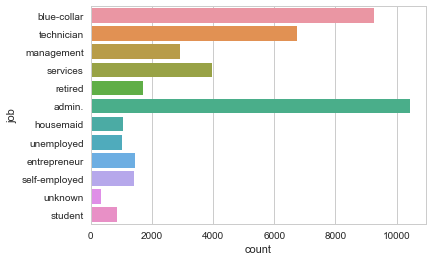

```python
sns.countplot(y="job", data=data)
plt.show()
```

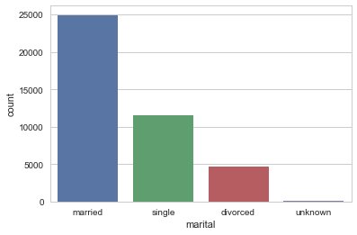

```python
sns.countplot(x="marital", data=data)
plt.show()
```

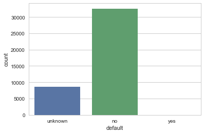

```python
sns.countplot(x="default", data=data)
plt.show()
```

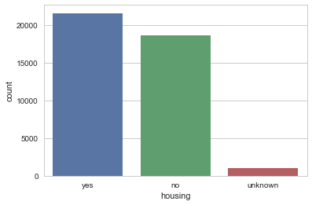

```python
sns.countplot(x="housing", data=data)
plt.show()
```

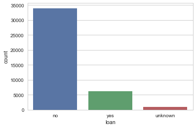

```python
sns.countplot(x="loan", data=data)
plt.show()
```

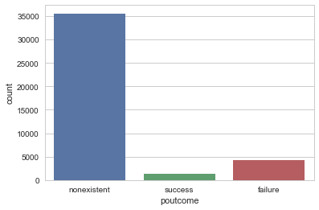

```python
sns.countplot(x="poutcome", data=data)
plt.show()
```

```python
data.drop(data.columns[[0, 3, 7, 8, 9, 10, 11, 12, 13, 15, 16, 17, 18, 19]], axis=1, inplace=True)
```

```python
data2 = pd.get_dummies(data, columns =['job', 'marital', 'default', 'housing', 'loan', 'poutcome'])
```

```python
data2.drop(data2.columns[[12, 16, 18, 21, 24]], axis=1, inplace=True)
data2.columns
```

```
Index(['y', 'job_admin.', 'job_blue-collar', 'job_entrepreneur',
       'job_housemaid', 'job_management', 'job_retired', 'job_self-employed',
       'job_services', 'job_student', 'job_technician', 'job_unemployed',
       'marital_divorced', 'marital_married', 'marital_single', 'default_no',
       'default_yes', 'housing_no', 'housing_yes', 'loan_no', 'loan_yes',
       'poutcome_failure', 'poutcome_nonexistent', 'poutcome_success'],
      dtype='object')
```

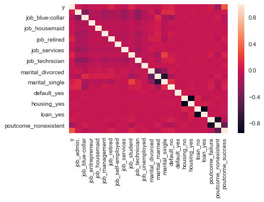

```python
sns.heatmap(data2.corr())
plt.show()
```

```python
X = data2.iloc[:,1:]
y = data2.iloc[:,0]
X_train, X_test, y_train, y_test = train_test_split(X, y, random_state=0)
```

```python
X_train.shape
```

```
(30891, 23)
```

```python
classifier = LogisticRegression(random_state=0)
classifier.fit(X_train, y_train)
```

```
LogisticRegression(C=1.0, class_weight=None, dual=False, fit_intercept=True,
          intercept_scaling=1, max_iter=100, multi_class='ovr', n_jobs=1,
          penalty='l2', random_state=0, solver='liblinear', tol=0.0001,
          verbose=0, warm_start=False)
```

```python
y_pred = classifier.predict(X_test)
from sklearn.metrics import confusion_matrix
confusion_matrix = confusion_matrix(y_test, y_pred)
print(confusion_matrix)
```

```
[[9046  110]
 [ 912  229]]
```

```python
print('Accuracy of logistic regression classifier on test set: {:.2f}'.format(classifier.score(X_test, y_test)))
```

```
Accuracy of logistic regression classifier on test set: 0.90
```

```python
from sklearn.metrics import classification_report
print(classification_report(y_test, y_pred))
```

```
             precision    recall  f1-score   support

          0       0.91      0.99      0.95      9156
          1       0.68      0.20      0.31      1141

avg / total       0.88      0.90      0.88     10297
```

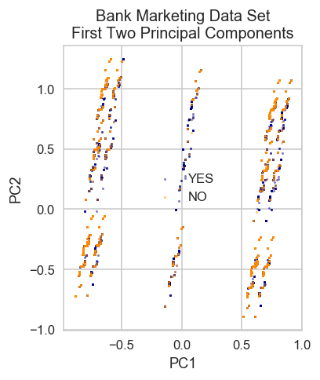

```python
from sklearn.decomposition import PCA
X = data2.iloc[:,1:]
y = data2.iloc[:,0]
pca = PCA(n_components=2).fit_transform(X)
X_train, X_test, y_train, y_test = train_test_split(pca, y, random_state=0)

plt.figure(dpi=120)
plt.scatter(pca[y.values==0,0], pca[y.values==0,1], alpha=0.5, label='YES', s=2, color='navy')
plt.scatter(pca[y.values==1,0], pca[y.values==1,1], alpha=0.5, label='NO', s=2, color='darkorange')
plt.legend()
plt.title('Bank Marketing Data Set\nFirst Two Principal Components')
plt.xlabel('PC1')
plt.ylabel('PC2')
plt.gca().set_aspect('equal')
plt.show()
```

```python
ans = np.linalg.svd(X_test @ X_test.T)
```

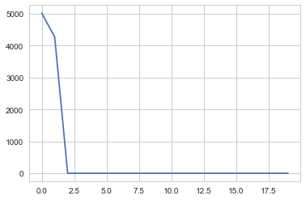

```python
plt.plot(ans[1][:20])
```

```python
X_test.shape
```

```
(10297, 2)
```

### Recap

- Quality mesures for regression problem
- Multicollinearity and regularization
- Probabilistic interpretation